# An Analysis of NOAA Storm Data to Determine Impacts of Storms to Human and Economic Activity

Stephen Duffy

January 27, 2016

## Synopsis

Storms affect people and property across the US every year. Since the 1950s, the highest toll to human activity has been caused by tornados, causing more fatalities and injuries than any other weather event.

In terms of economic damages, flooding causes the most property damage and drought causes the most damage to crops. However, when the two values are combined, flooding far outweighs any other weather activities for economic costliness.

The following provides a view into the methodology and outcomes of this analysis.

## Data Processing

First load needed libraries and then read the data file into R

```r
##First, load needed libraries
library(plyr)
library(dplyr)
```

```r
library(reshape2)
library(ggplot2)
options(scipen=999)

##This code looks for the zipped file in your working directory and downloads it if not present
if (!file.exists("repdata-data-StormData.csv.bz2")) {
    download.file("https://d396qusza40orc.cloudfront.net/repdata%2Fdata%2FStormData.csv.bz2",
                  destfile = "repdata-data-StormData.csv.bz2")}

##read.csv can read .bz2 files directly, this will take some time.
noaa_data <- read.csv("repdata-data-StormData.csv.bz2")

##and a quick view of the data
str(noaa_data)
```

```
## 'data.frame':    902297 obs. of  37 variables:
##  $ STATE__   : num  1 1 1 1 1 1 1 1 1 1 ...
##  $ BGN_DATE  : Factor w/ 16335 levels "1/1/1966 0:00:00",..: 6523 6523 4242 11116 2224 2224 2260 383 3980 3980 ...
##  $ BGN_TIME  : Factor w/ 3608 levels "00:00:00 AM",..: 272 287 2705 1683 2584 3186 242 1683 3186 3186 ...
##  $ TIME_ZONE : Factor w/ 22 levels "ADT","AKS","AST",..: 7 7 7 7 7 7 7 7 7 7 ...
##  $ COUNTY    : num  97 3 57 89 43 77 9 123 125 57 ...
##  $ COUNTYNAME: Factor w/ 29601 levels "","5NM E OF MACKINAC BRIDGE TO PRESQUE ISLE LT MI",..: 13513 1873 4598 10592 4372 10094 1973 23873 24418 4598 ...
##  $ STATE     : Factor w/ 72 levels "AK","AL","AM",..: 2 2 2 2 2 2 2 2 2 2 ...
##  $ EVTYPE    : Factor w/ 985 levels "   HIGH SURF ADVISORY",..: 834 834 834 834 834 834 834 834 834 834 ...
##  $ BGN_RANGE : num  0 0 0 0 0 0 0 0 0 0 ...
##  $ BGN_AZI   : Factor w/ 35 levels "","  N"," NW",..: 1 1 1 1 1 1 1 1 1 1 ...
##  $ BGN_LOCATI: Factor w/ 54429 levels "","- 1 N Albion",..: 1 1 1 1 1 1 1 1 1 1 ...
##  $ END_DATE  : Factor w/ 6663 levels "","1/1/1993 0:00:00",..: 1 1 1 1 1 1 1 1 1 1 ...
##  $ END_TIME  : Factor w/ 3647 levels ""," 0900CST",..: 1 1 1 1 1 1 1 1 1 1 ...
##  $ COUNTY_END: num  0 0 0 0 0 0 0 0 0 0 ...
```

[output cut: 23 more lines]

Then perform some cleanup of the data, such as trimming leading and trailing blanks spaces, capitalizing columns for matching, and converting values.

```r
##Trim leading and trailing blank spaces in columns we will use
trim <- function (x) gsub("^\\s+|\\s+$", "", x)
noaa_data$EVTYPE <- trim(noaa_data$EVTYPE)
noaa_data$STATE <- trim(noaa_data$STATE)
noaa_data$PROPDMGEXP <- trim(noaa_data$PROPDMGEXP)
noaa_data$CROPDMGEXP <- trim(noaa_data$CROPDMGEXP)

##Capitalize some messy columns we need to use
noaa_data$PROPDMGEXP <- toupper(noaa_data$PROPDMGEXP)
noaa_data$CROPDMGEXP <- toupper(noaa_data$CROPDMGEXP)

##Convert factors to dates
noaa_data$BGN_DATE <- as.Date(noaa_data$BGN_DATE,format = "%m/%d/%Y %H:%M:%S")
noaa_data$END_DATE <- as.Date(noaa_data$END_DATE,format = "%m/%d/%Y %H:%M:%S")
```

The NOAA data has damages to crops and property separated into two columns. The first is a numeric value and the second is an exponent, such as “K” or “M”. This analysis needs actual numbers and so the numeric value will be multiplied by the exponent value to get an actual value, e.g., H = 100, K = 1000, etc. What’s more, there are other characters in the exponent column, such as numbers, plus signs, and dashes. For any row that has a value higher than 0 in the numeric column, but a non-obvious exponent, I purport to multiply that by 1000, as 97-99 percent of the exponents are “K”, that is 1,000.

```r
##This is the justification for using a 1,000 multiplier
cropexpcount <- noaa_data %>% count(CROPDMGEXP, sort = TRUE)
propexpcount <- noaa_data %>% count(PROPDMGEXP, sort = TRUE)
cropexpcount$Pct <- round(cropexpcount[,2] / sum(cropexpcount[2:7,2]),3)
propexpcount$Pct <- round(propexpcount[,2] / sum(propexpcount[2:17,2]),3)

crop_perc <- as.data.frame(cropexpcount)
prop_perc <- as.data.frame(propexpcount)

crop_k <- as.data.frame(cropexpcount)[2,3] * 100
prop_k <- as.data.frame(propexpcount)[2,3] * 100
```

You can see the value of “K” has 97.3% of exponent values in the property damage column and it has a value of 99.3% in the crop damage column.

Next, create new columns that have actual numeric values based on the number and exponent

```r
propmult <- ifelse(noaa_data$PROPDMGEXP == 'M', 1000000,
                  ifelse(noaa_data$PROPDMGEXP == "B", 1000000000,
                        ifelse(noaa_data$PROPDMGEXP == "H", 100,
                               1000)))
noaa_data$PROPDMGNUMBER <- noaa_data$PROPDMG * propmult



cropmult <- ifelse(noaa_data$CROPDMGEXP == 'M', 1000000,
                  ifelse(noaa_data$CROPDMGEXP == "B", 1000000000,
                        ifelse(noaa_data$CROPDMGEXP == "H", 100,
                              1000)))
noaa_data$CROPDMGNUMBER <- noaa_data$CROPDMG * cropmult

##There are two new columns at the end with full values
str(noaa_data)
```

```
## 'data.frame':    902297 obs. of  39 variables:
##  $ STATE__      : num  1 1 1 1 1 1 1 1 1 1 ...
##  $ BGN_DATE     : Date, format: "1950-04-18" "1950-04-18" ...
##  $ BGN_TIME     : Factor w/ 3608 levels "00:00:00 AM",..: 272 287 2705 1683 2584 3186 242 1683 3186 3186 ...
##  $ TIME_ZONE    : Factor w/ 22 levels "ADT","AKS","AST",..: 7 7 7 7 7 7 7 7 7 7 ...
##  $ COUNTY       : num  97 3 57 89 43 77 9 123 125 57 ...
##  $ COUNTYNAME   : Factor w/ 29601 levels "","5NM E OF MACKINAC BRIDGE TO PRESQUE ISLE LT MI",..: 13513 1873 4598 10592 4372 10094 1973 23873 24418 4598 ...
##  $ STATE        : chr  "AL" "AL" "AL" "AL" ...
##  $ EVTYPE       : chr  "TORNADO" "TORNADO" "TORNADO" "TORNADO" ...
##  $ BGN_RANGE    : num  0 0 0 0 0 0 0 0 0 0 ...
##  $ BGN_AZI      : Factor w/ 35 levels "","  N"," NW",..: 1 1 1 1 1 1 1 1 1 1 ...
##  $ BGN_LOCATI   : Factor w/ 54429 levels "","- 1 N Albion",..: 1 1 1 1 1 1 1 1 1 1 ...
##  $ END_DATE     : Date, format: NA NA ...
##  $ END_TIME     : Factor w/ 3647 levels ""," 0900CST",..: 1 1 1 1 1 1 1 1 1 1 ...
##  $ COUNTY_END   : num  0 0 0 0 0 0 0 0 0 0 ...
```

[output cut: 25 more lines]

There are now two new columns with full numeric values at the end

## Results

### The Impacts of Storms on Human Activity

To determine the impacts of storms on human activity, first group the data by event type and sum totalinjuries and total fatalities, then create a new column that is the sum of both.

```r
pop_health <- noaa_data[,c(8,23,24)] %>%
                group_by(EVTYPE) %>%
                summarise_each(funs(sum))

pop_health$TOTALHARM <- pop_health$FATALITIES + pop_health$INJURIES


max_fatal <- arrange(pop_health, desc(FATALITIES))[1,1:2]
max_injury <- arrange(pop_health, desc(INJURIES))[1,c(1,3)]
max_comb <- arrange(pop_health, desc(TOTALHARM))[1,c(1,4)]
```

With the data ready, it is possible to determine what event is costliest to human life in terms of:

Fatalities: TORNADO, 5633 people.

Injuries: TORNADO, 91346 people.

Combined: TORNADO, 96979 people.

The next five events that are costliest to human life are as follows:

```r
next_five_pop <- arrange(pop_health, desc(TOTALHARM))[2:6,c(1,4)]

next_five_pop
```

```
## Source: local data frame [5 x 2]
##
##           EVTYPE TOTALHARM
##            (chr)     (dbl)
## 1 EXCESSIVE HEAT      8428
## 2      TSTM WIND      7461
## 3          FLOOD      7259
## 4      LIGHTNING      6046
## 5           HEAT      3037
```

Finally, this is a view of total injuries and fatalities per year due to tornados

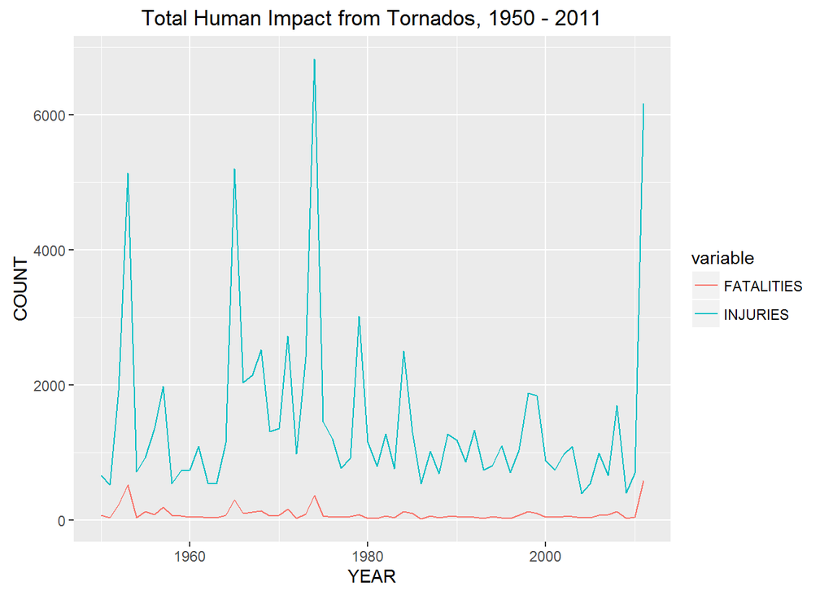

```r
##make a plot of injuries and fatalities by year
noaa_data$YEAR <- format(noaa_data$BGN_DATE,'%Y')
pop_health_yr <- subset(noaa_data, EVTYPE == "TORNADO")[,c(40,23,24)] %>%
    group_by(YEAR) %>%
    summarise_each(funs(sum))

melt_pop <- melt(pop_health_yr, id.vars = "YEAR")
melt_pop[,1] <- as.numeric(as.character(melt_pop[,1]))
ggplot(data = melt_pop, aes(x=YEAR,y=value)) +
       geom_path(aes(colour = variable)) +
       ggtitle("Total Human Impact from Tornados, 1950 - 2011") +
       ylab("COUNT")
```

### The Impacts of Storms on Economic Activity

To determine the impacts of storms on human activity, follow the same steps as before but instead of using injuries and fatalities use the two columns of numeric damage values created earlier.

```r
econ_dmg <- noaa_data[,c(8,38,39)] %>%
    group_by(EVTYPE) %>%
    summarise_each(funs(sum))

econ_dmg$TOTDAMAGE <- econ_dmg$PROPDMGNUMBER + econ_dmg$CROPDMGNUMBER

max_property <- arrange(econ_dmg, desc(PROPDMGNUMBER))[1,1:2]
max_crop <- arrange(econ_dmg, desc(CROPDMGNUMBER))[1,c(1,3)]
max_totdmg <- arrange(econ_dmg, desc(TOTDAMAGE))[1,c(1,4)]
```

Crops and property tend to have different events that create the most damage.

The event that causes the most damage to property is FLOOD and the amount of damage cause by it is $144,657,716,800.

The event that causes the most damage to crops is DROUGHT and the amount of damage cause by it is $13,972,566,000.

Finally, the event that causes the most damage overall, to both property and crops combined is FLOOD and the amount of damage cause by it is $150,319,685,250.

The next five most damaging events are as follows:

```r
next_five_dmg <- arrange(econ_dmg, desc(TOTDAMAGE))[2:6,c(1,4)]

next_five_dmg
```

```
## Source: local data frame [5 x 2]
##
##              EVTYPE   TOTDAMAGE
##               (chr)       (dbl)
## 1 HURRICANE/TYPHOON 71913712800
## 2           TORNADO 57352572290
## 3       STORM SURGE 43323541000
## 4              HAIL 18758567370
## 5       FLASH FLOOD 17562735710
```

Lastly, in terms of total damage not all states in the US are equal. The barplot below shows total damages to crops and property by state, for the top ten states with damage. California is the clear leader in damages, likely due to high property values in areas with wild fires, mud slides, and earthquakes, as well as having large amounts of farm land in a drough-prone area of the country.

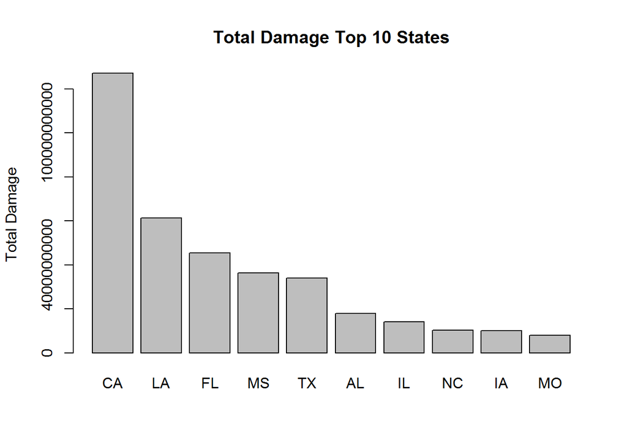

```r
econ_dmg_st <- noaa_data[,c(7,38,39)] %>%
    group_by(STATE) %>%
    summarise_each(funs(sum))

econ_dmg_st$TOTAL <- (econ_dmg_st$PROPDMGNUMBER + econ_dmg_st$CROPDMGNUMBER)
econ_dmg_st <- arrange(econ_dmg_st[,c(1,4)],desc(TOTAL))[1:10,]

barplot(econ_dmg_st$TOTAL, names.arg = econ_dmg_st$STATE, ylab = "Total Damage", main =
            "Total Damage Top 10 States")
```